# Project 1

Brant Armstrong

2022-09-11

# **Purpose**

To create generic functions that can read in csv files located online through their url’s then process that data before graphing various summaries that can be modified depending on user input.

# **Data Processing**

The only packages needed for this project are tidyverse and should be loaded in beforehand.

```r
library(tidyverse)
```

We begin by doing all data processing without functions, starting with reading in the csv, converting it to a tibble, sub setting the data to only variables of interest, then pivoting the data frame to long format before finally doing some simple manipulation to create variables for `year` and `educode`.

```r
sheet1 <- read_csv("https://www4.stat.ncsu.edu/~online/datasets/EDU01a.csv")
data1 <- sheet1 %>%
  as_tibble(sheet1) %>%
  select(Area_name, STCOU, ends_with("D")) %>%
  rename(area_name = Area_name) %>%
  pivot_longer(cols = 3:12, names_to = "educode" , values_to ="enrollment") %>%
  mutate(year = as.numeric(substr(educode,8,9))) %>%
  mutate(year = if_else(year >=80, paste0(19,year),
                  if_else(year <= 80,paste0(200,year), "error"))) %>%
  mutate(educode = substr(educode,1,7))
```

Next, we conduct some more complicated variable creation using an index to separate the county data from the state date using the `area_name` variable. Then we created a `state` variable for the `county` data frame and a `division` variable for the `state` data frame; once again using the `area_name` variable.

```r
  row_numbers1 <- grep(pattern = ", \\w\\w", data1$area_name)
  row_numbers2 <- -row_numbers1
  county_data <- slice(data1,row_numbers1)
  class(county_data) <- c("county", class(county_data))
  state_data <- slice(data1,row_numbers2)
  class(state_data) <- c("state", class(state_data))

  county_data %>%
    mutate( state = str_sub(area_name,-2,-1))
```

```
## # A tibble: 31,450 × 6
##    area_name   STCOU educode enrollment year  state
##    <chr>       <chr> <chr>        <dbl> <chr> <chr>
##  1 Autauga, AL 01001 EDU0101       6829 1987  AL
##  2 Autauga, AL 01001 EDU0101       6900 1988  AL
##  3 Autauga, AL 01001 EDU0101       6920 1989  AL
##  4 Autauga, AL 01001 EDU0101       6847 1990  AL
##  5 Autauga, AL 01001 EDU0101       7008 1991  AL
##  6 Autauga, AL 01001 EDU0101       7137 1992  AL
##  7 Autauga, AL 01001 EDU0101       7152 1993  AL
##  8 Autauga, AL 01001 EDU0101       7381 1994  AL
##  9 Autauga, AL 01001 EDU0101       7568 1995  AL
## 10 Autauga, AL 01001 EDU0101       7834 1996  AL
## # … with 31,440 more rows
```

```r
  division1 <- c("CONNECTICUT","MAINE","MASSACHUSETTS","NEW HAMPSHIRE","RHODE ISLAND","VERMONT")
  division2 <- c("NEW JERSEY","NEW YORK","PENNSYLVANIA")
  division3 <- c("ILLINOIS","INDIANA","MICHIGAN","OHIO","WISCONSIN")
  division4 <- c("IOWA","KANSAS","MINNESOTA","MISSOURI","NEBRASKA","NORTH DAKOTA","SOUTH DAKOTA")
  division5 <- c("DELAWARE","FLORIDA","GEORGIA","MARYLAND","NORTH CAROLINA","SOUTH CAROLINA","VIRGINIA","DISTRICT OF COLUMBIA","District of Columbia","WEST VIRGINIA")
  division6 <- c("ALABAMA","KENTUCKY","MISSISSIPPI","TENNESSEE")
  division7 <- c("ARKANSAS","LOUISIANA","OKLAHOMA","TEXAS")
  division8 <- c("ARIZONA","COLORADO","IDAHO","MONTANA","NEVADA","NEW MEXICO","UTAH","WYOMING")
  division9 <- c("ALASKA","CALIFORNIA","HAWAII","OREGON","WASHINGTON")

  state_data %>%
    mutate(division = if_else(area_name %in% division1,"New England",
                        if_else(area_name %in% division2, "Mid-Atlantic",
                          if_else(area_name %in% division3, "East North Central",
                            if_else(area_name %in% division4, "West North Central",
                              if_else(area_name %in% division5, "South Atlantic",
                                if_else(area_name %in% division6, "East South Central",
                                  if_else(area_name %in% division7, "West South Central",
                                    if_else(area_name %in% division8, "Mountain",
                                      if_else(area_name %in% division9, "Pacific","ERROR"))))))))))
```

```
## # A tibble: 530 × 6
##    area_name     STCOU educode enrollment year  division
##    <chr>         <chr> <chr>        <dbl> <chr> <chr>
##  1 UNITED STATES 00000 EDU0101   40024299 1987  ERROR
##  2 UNITED STATES 00000 EDU0101   39967624 1988  ERROR
##  3 UNITED STATES 00000 EDU0101   40317775 1989  ERROR
##  4 UNITED STATES 00000 EDU0101   40737600 1990  ERROR
##  5 UNITED STATES 00000 EDU0101   41385442 1991  ERROR
##  6 UNITED STATES 00000 EDU0101   42088151 1992  ERROR
##  7 UNITED STATES 00000 EDU0101   42724710 1993  ERROR
##  8 UNITED STATES 00000 EDU0101   43369917 1994  ERROR
##  9 UNITED STATES 00000 EDU0101   43993459 1995  ERROR
## 10 UNITED STATES 00000 EDU0101   44715737 1996  ERROR
## # … with 520 more rows
```

# **Function Creation**

Now we begin building functions that are capable of doing the above processing.

## **Function 1**

Reads in a data frame, saves it as a tibble, and finally pivots it to long format.

```r
read_and_transpose <- function(df, value = "enrollment"){
  df %>%
    as_tibble(df) %>%
    select(Area_name, STCOU, ends_with("D")) %>%
    rename(area_name = Area_name) %>%
    pivot_longer(cols = 3:12, names_to = "educode" , values_to = value)
}
```

## **Function 2**

Takes the results of function 1 then creates the `year` and `educode` variables.

```r
years_and_codes <- function(df){
  df %>%
  mutate(year = as.numeric(substr(educode,8,9))) %>%
  mutate(year = as.numeric(if_else(year >=30, paste0(19,year),
                  if_else(year <= 25,paste0(200,year), "error")))) %>%
  mutate(educode = substr(educode,1,7))
}
```

## **Function 3**

Takes a `county` data frame and creates the `state` variable.

```r
get_state <- function(df){
    df %>%
    mutate( state = str_sub(area_name,-2,-1))
}
```

## **Function 4**

Takes a `state` data frame and creates the `division` variable.

```r
get_division <- function(df){
  division1 <- c("CONNECTICUT","MAINE","MASSACHUSETTS","NEW HAMPSHIRE","RHODE ISLAND","VERMONT")
  division2 <- c("NEW JERSEY","NEW YORK","PENNSYLVANIA")
  division3 <- c("ILLINOIS","INDIANA","MICHIGAN","OHIO","WISCONSIN")
  division4 <- c("IOWA","KANSAS","MINNESOTA","MISSOURI","NEBRASKA","NORTH DAKOTA","SOUTH DAKOTA")
  division5 <- c("DELAWARE","FLORIDA","GEORGIA","MARYLAND","NORTH CAROLINA","SOUTH CAROLINA","VIRGINIA","DISTRICT OF COLUMBIA","District of Columbia","WEST VIRGINIA")
  division6 <- c("ALABAMA","KENTUCKY","MISSISSIPPI","TENNESSEE")
  division7 <- c("ARKANSAS","LOUISIANA","OKLAHOMA","TEXAS")
  division8 <- c("ARIZONA","COLORADO","IDAHO","MONTANA","NEVADA","NEW MEXICO","UTAH","WYOMING")
  division9 <- c("ALASKA","CALIFORNIA","HAWAII","OREGON","WASHINGTON")
  df %>%
    mutate(division = if_else(area_name %in% division1,"New England",
                        if_else(area_name %in% division2, "Mid-Atlantic",
                          if_else(area_name %in% division3, "East North Central",
                            if_else(area_name %in% division4, "West North Central",
                              if_else(area_name %in% division5, "South Atlantic",
                                if_else(area_name %in% division6, "East South Central",
                                  if_else(area_name %in% division7, "West South Central",
                                    if_else(area_name %in% division8, "Mountain",
                                      if_else(area_name %in% division9, "Pacific","ERROR"))))))))))
}
```

## **Function 5**

```r
county_and_state <- function(df){
  row_numbers1 <- grep(pattern = ", \\w\\w", df$area_name)
  row_numbers2 <- -row_numbers1
  county_data <- slice(df,row_numbers1)
  class(county_data) <- c("county", class(county_data))
  state_data <- slice(df,row_numbers2)
  class(state_data) <- c("state", class(state_data))
  county_data <-get_state(county_data)
  state_data <- get_division(state_data)
  return(list(county = county_data, state = state_data))
}
```

## **Wrapper Function**

Combines functions 1-5 with the option to override the `enrollment` variable name to one of the user’s choosing.

```r
my_wrapper <- function(url, value = "enrollment", ...) {
  a <- read_csv(url)
  b <- read_and_transpose(a, value,...)
  c <- years_and_codes(b, ...)
  d <- county_and_state(c,...)
  return(d)
}
```

## **Wrapper Function in Action**

Below is proof of functionality. By running the wrapper function on two different url’s, we get two lists that contain the `county` and `state` data frames for that csv.

```r
wrap1 <- my_wrapper("https://www4.stat.ncsu.edu/~online/datasets/EDU01b.csv")
wrap2 <- my_wrapper("https://www4.stat.ncsu.edu/~online/datasets/EDU01a.csv")
wrap1
```

```
## $county
## # A tibble: 31,450 × 6
##    area_name   STCOU educode enrollment  year state
##    <chr>       <chr> <chr>        <dbl> <dbl> <chr>
##  1 Autauga, AL 01001 EDU0101       8099  1997 AL
##  2 Autauga, AL 01001 EDU0101       8211  1998 AL
##  3 Autauga, AL 01001 EDU0101       8489  1999 AL
##  4 Autauga, AL 01001 EDU0102       8912  2000 AL
##  5 Autauga, AL 01001 EDU0102       8626  2001 AL
##  6 Autauga, AL 01001 EDU0102       8762  2002 AL
##  7 Autauga, AL 01001 EDU0152       9105  2003 AL
##  8 Autauga, AL 01001 EDU0152       9200  2004 AL
##  9 Autauga, AL 01001 EDU0152       9559  2005 AL
## 10 Autauga, AL 01001 EDU0152       9652  2006 AL
## # … with 31,440 more rows
##
## $state
## # A tibble: 530 × 6
##    area_name     STCOU educode enrollment  year division
##    <chr>         <chr> <chr>        <dbl> <dbl> <chr>
##  1 UNITED STATES 00000 EDU0101   44534459  1997 ERROR
##  2 UNITED STATES 00000 EDU0101   46245814  1998 ERROR
##  3 UNITED STATES 00000 EDU0101   46368903  1999 ERROR
##  4 UNITED STATES 00000 EDU0102   46818690  2000 ERROR
##  5 UNITED STATES 00000 EDU0102   47127066  2001 ERROR
##  6 UNITED STATES 00000 EDU0102   47606570  2002 ERROR
##  7 UNITED STATES 00000 EDU0152   48506317  2003 ERROR
##  8 UNITED STATES 00000 EDU0152   48693287  2004 ERROR
##  9 UNITED STATES 00000 EDU0152   48978555  2005 ERROR
## 10 UNITED STATES 00000 EDU0152   49140702  2006 ERROR
## # … with 520 more rows
```

```r
wrap2
```

```
## $county
## # A tibble: 31,450 × 6
##    area_name   STCOU educode enrollment  year state
##    <chr>       <chr> <chr>        <dbl> <dbl> <chr>
##  1 Autauga, AL 01001 EDU0101       6829  1987 AL
##  2 Autauga, AL 01001 EDU0101       6900  1988 AL
##  3 Autauga, AL 01001 EDU0101       6920  1989 AL
##  4 Autauga, AL 01001 EDU0101       6847  1990 AL
##  5 Autauga, AL 01001 EDU0101       7008  1991 AL
##  6 Autauga, AL 01001 EDU0101       7137  1992 AL
##  7 Autauga, AL 01001 EDU0101       7152  1993 AL
##  8 Autauga, AL 01001 EDU0101       7381  1994 AL
##  9 Autauga, AL 01001 EDU0101       7568  1995 AL
## 10 Autauga, AL 01001 EDU0101       7834  1996 AL
## # … with 31,440 more rows
##
## $state
## # A tibble: 530 × 6
##    area_name     STCOU educode enrollment  year division
##    <chr>         <chr> <chr>        <dbl> <dbl> <chr>
##  1 UNITED STATES 00000 EDU0101   40024299  1987 ERROR
##  2 UNITED STATES 00000 EDU0101   39967624  1988 ERROR
##  3 UNITED STATES 00000 EDU0101   40317775  1989 ERROR
##  4 UNITED STATES 00000 EDU0101   40737600  1990 ERROR
##  5 UNITED STATES 00000 EDU0101   41385442  1991 ERROR
##  6 UNITED STATES 00000 EDU0101   42088151  1992 ERROR
##  7 UNITED STATES 00000 EDU0101   42724710  1993 ERROR
##  8 UNITED STATES 00000 EDU0101   43369917  1994 ERROR
##  9 UNITED STATES 00000 EDU0101   43993459  1995 ERROR
## 10 UNITED STATES 00000 EDU0101   44715737  1996 ERROR
## # … with 520 more rows
```

## **Combination Function**

Now, we created a function that takes the results of our wrapper function and merges the `county` and `state` data frames from our outputs together as seen below

```r
match_combine <- function(df1,df2){
  county_merge <- bind_rows(df1$county, df2$county)
  state_merge <- bind_rows(df1$state, df2$state)
  return(list(county = county_merge,state = state_merge))
}
wrap_combine <- match_combine(wrap1, wrap2)
wrap_combine
```

```
## $county
## # A tibble: 62,900 × 6
##    area_name   STCOU educode enrollment  year state
##    <chr>       <chr> <chr>        <dbl> <dbl> <chr>
##  1 Autauga, AL 01001 EDU0101       8099  1997 AL
##  2 Autauga, AL 01001 EDU0101       8211  1998 AL
##  3 Autauga, AL 01001 EDU0101       8489  1999 AL
##  4 Autauga, AL 01001 EDU0102       8912  2000 AL
##  5 Autauga, AL 01001 EDU0102       8626  2001 AL
##  6 Autauga, AL 01001 EDU0102       8762  2002 AL
##  7 Autauga, AL 01001 EDU0152       9105  2003 AL
##  8 Autauga, AL 01001 EDU0152       9200  2004 AL
##  9 Autauga, AL 01001 EDU0152       9559  2005 AL
## 10 Autauga, AL 01001 EDU0152       9652  2006 AL
## # … with 62,890 more rows
##
## $state
## # A tibble: 1,060 × 6
##    area_name     STCOU educode enrollment  year division
##    <chr>         <chr> <chr>        <dbl> <dbl> <chr>
##  1 UNITED STATES 00000 EDU0101   44534459  1997 ERROR
##  2 UNITED STATES 00000 EDU0101   46245814  1998 ERROR
##  3 UNITED STATES 00000 EDU0101   46368903  1999 ERROR
##  4 UNITED STATES 00000 EDU0102   46818690  2000 ERROR
##  5 UNITED STATES 00000 EDU0102   47127066  2001 ERROR
##  6 UNITED STATES 00000 EDU0102   47606570  2002 ERROR
##  7 UNITED STATES 00000 EDU0152   48506317  2003 ERROR
##  8 UNITED STATES 00000 EDU0152   48693287  2004 ERROR
##  9 UNITED STATES 00000 EDU0152   48978555  2005 ERROR
## 10 UNITED STATES 00000 EDU0152   49140702  2006 ERROR
## # … with 1,050 more rows
```

# **Writing Generic Functions for Summarizing**

Now we will write two generic functions to summarize our data with one for `county` level data and one for `state` level data

## **Function for Plotting State Data**

Takes in a `state` data frame and the option to change the name of the `enrollment` variable then graphs mean `enrollment` by year for each `division` excluding any that have the value “ERROR”.

```r
plot.state <- function(df, var_name = "enrollment"){
  new_df <- df %>%
  filter(division != "ERROR") %>%
  group_by(division, year) %>%
  summarize(mean_enrollment = mean(get(var_name)))
  ggplot(new_df, aes(x = year, y = mean_enrollment, color = division)) + geom_line()
}
```

## **Function for Plotting County Data**

Takes in a `county` data frame with the options to change the name of the `enrollment` variable, select the state of interest, specify whether to only show the top or bottom counties, and finally how many counties to graph.

```r
plot.county <- function(df, var_name = "enrollment", state_filter = "NC", value_choice = "top", x = 5 ){
  area_df <- df %>%
  filter(state == state_filter) %>%
  group_by(area_name) %>%
  summarize (mean_enrollment = mean(get(var_name))) %>%
  arrange(case_when(
    value_choice == "top" ~ desc(mean_enrollment),
    value_choice == "bottom" ~ mean_enrollment)) %>%
  slice_head(n = x)

  filtered_df <- df %>%
  filter(df$area_name %in% area_df$area_name)
ggplot(filtered_df, aes(x = year, y = get(var_name), color = area_name)) + geom_line()
}
```

# **Combining the Wrapper and Plotting Functions together**

## **Using the Two Data Sets Shown Earlier**

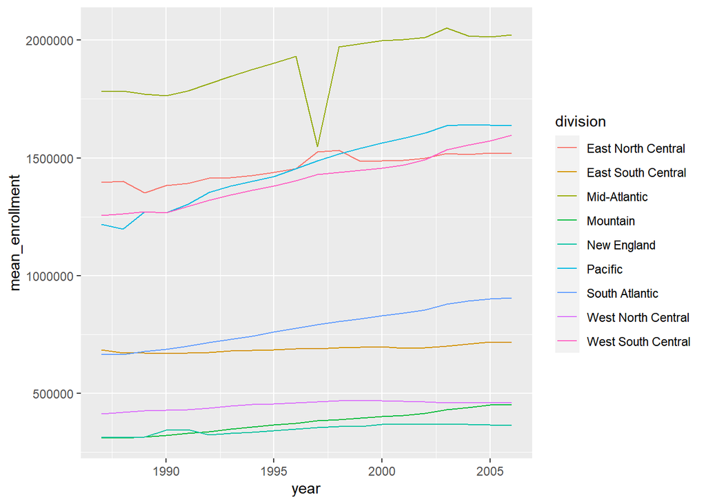

```r
edu1 <- my_wrapper("https://www4.stat.ncsu.edu/~online/datasets/EDU01a.csv")
edu2 <- my_wrapper("https://www4.stat.ncsu.edu/~online/datasets/EDU01b.csv")
edu_merge1 <- match_combine(edu1, edu2)
plot.state(edu_merge1$state)
```

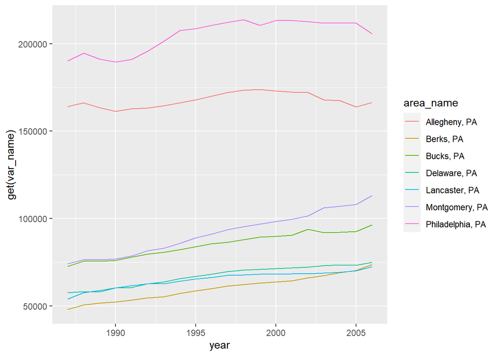

```r
plot.county(edu_merge1$county, "enrollment", "PA", "top", 7)
```

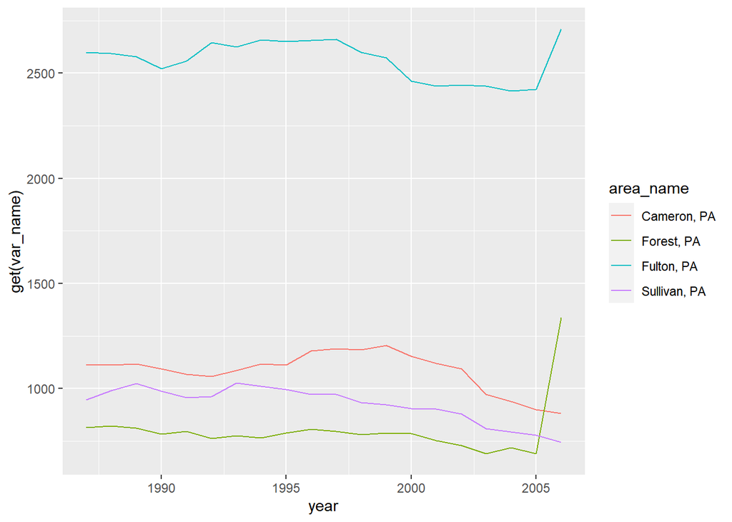

```r
plot.county(edu_merge1$county, "enrollment", "PA", "bottom", 4)
```

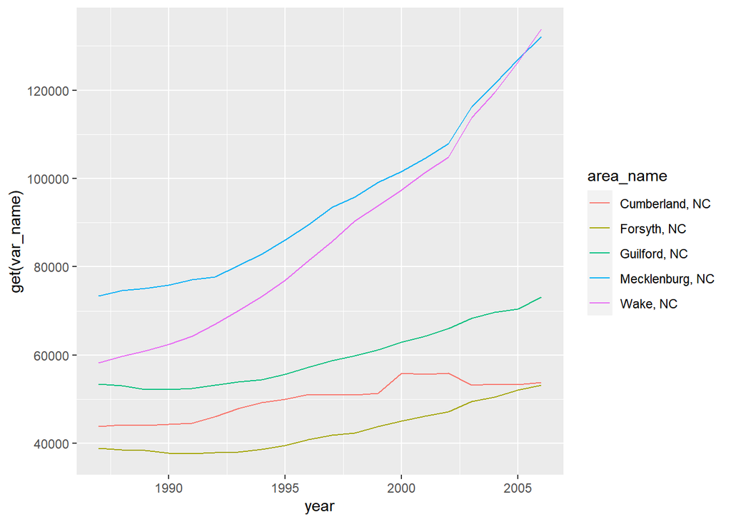

```r
plot.county(edu_merge1$county)
```

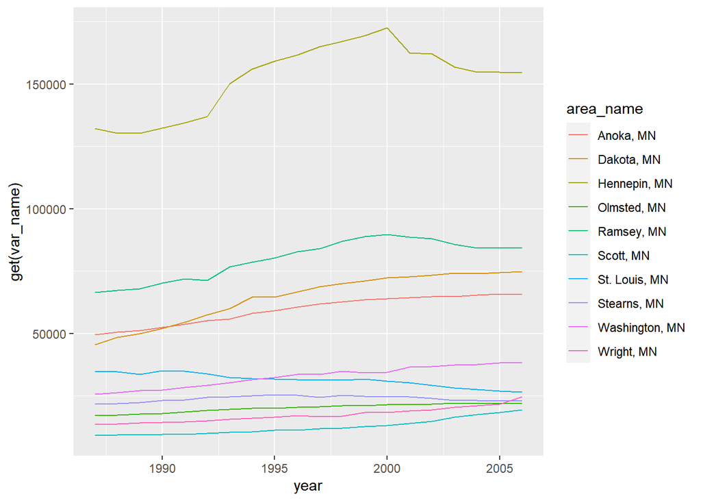

```r
plot.county(edu_merge1$county, "enrollment", "MN", "top", 10)
```

## **Using Four New Data Sets**

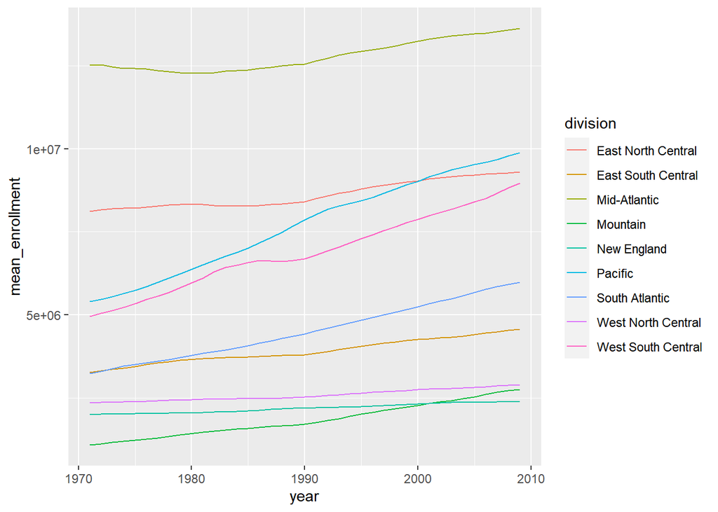

```r
edu3 <- my_wrapper("https://www4.stat.ncsu.edu/~online/datasets/PST01a.csv")
edu4 <- my_wrapper("https://www4.stat.ncsu.edu/~online/datasets/PST01b.csv")
edu5 <- my_wrapper("https://www4.stat.ncsu.edu/~online/datasets/PST01c.csv")
edu6 <- my_wrapper("https://www4.stat.ncsu.edu/~online/datasets/PST01d.csv")
edu_merge2 <- match_combine(edu3, edu4)
edu_merge3 <- match_combine(edu5, edu6)
edu_merge4 <- match_combine(edu_merge2, edu_merge3)
plot.state(edu_merge4$state)
```

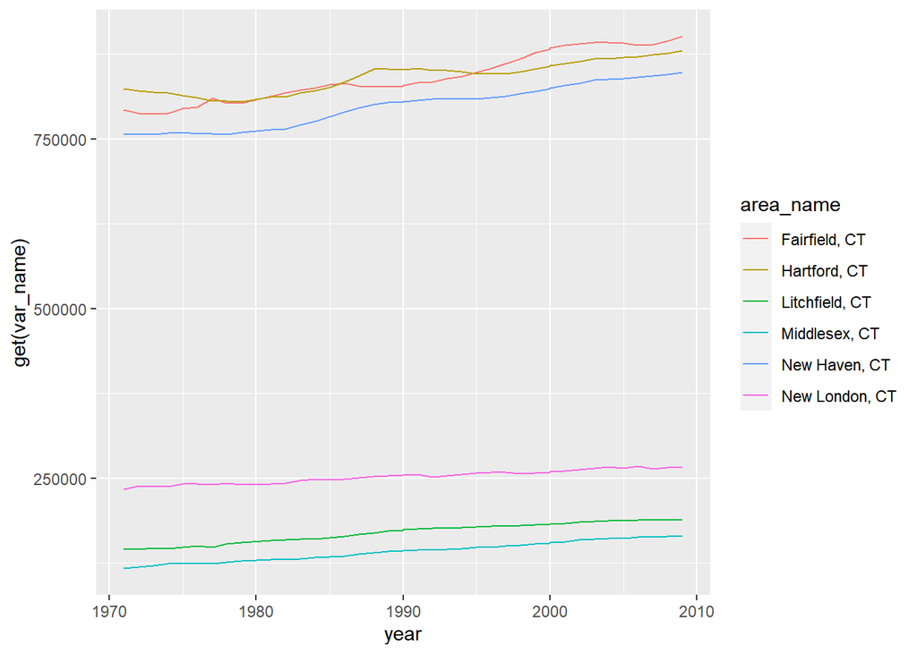

```r
plot.county(edu_merge4$county, "enrollment", "CT", "top", 6)
```

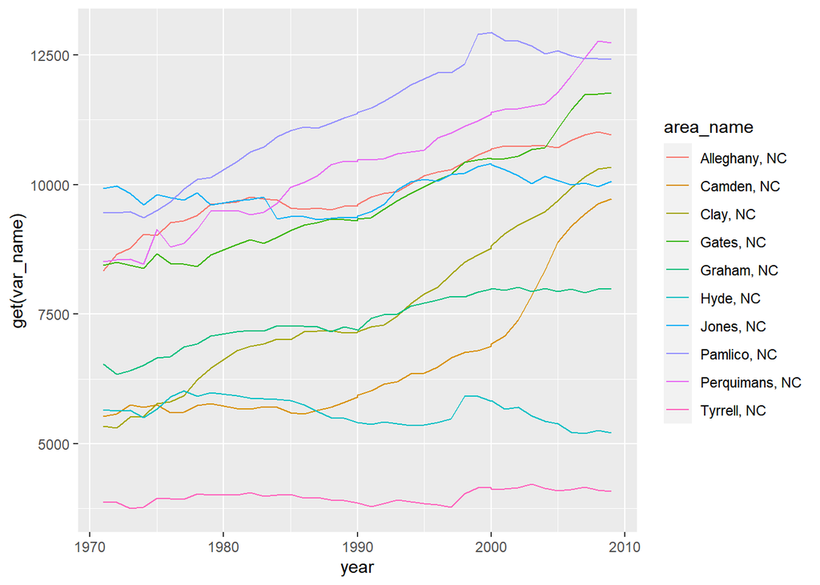

```r
plot.county(edu_merge4$county, "enrollment", "NC", "bottom", 10)
```

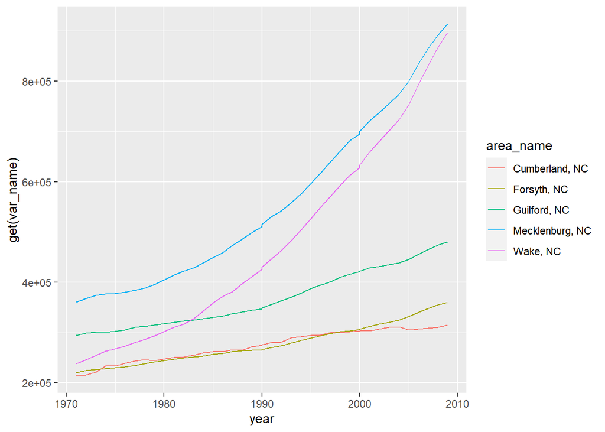

```r
plot.county(edu_merge4$county)
```

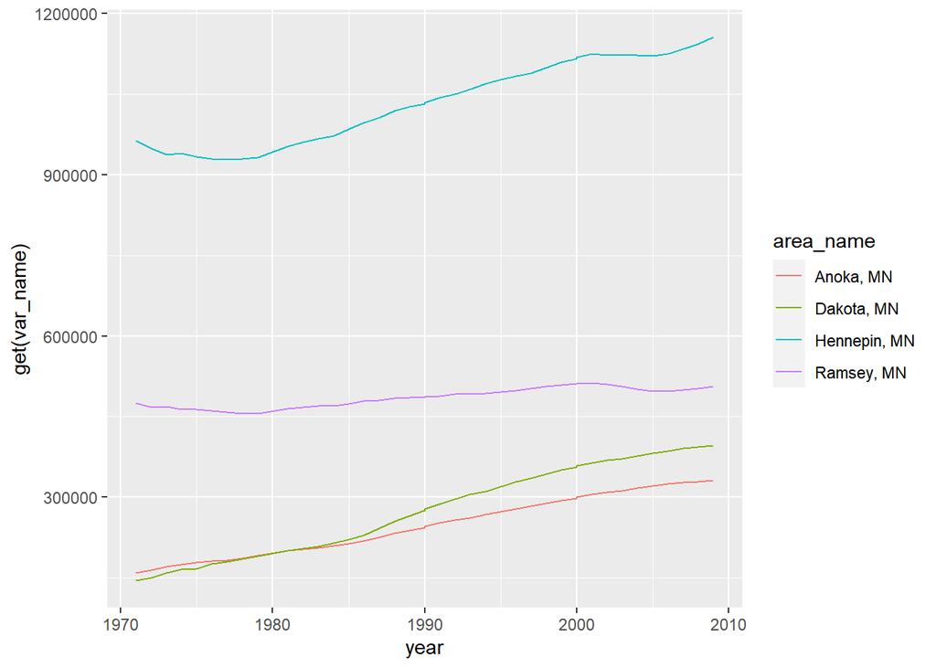

```r
plot.county(edu_merge4$county, "enrollment", "MN", "top", 4)
```